##### *Please submit your knitted .pdf file along with the corresponding R markdown (.rmd) via Courseworks by 11:59pm on Monday, March 4th.*

##### Remember to think carefully about what code you include in your knitted document. Only include code chunks that you need to generate the plots and statistics to answer the questions below. Don’t include code from your working R script (that we started in class) that was only used to inspect and validate your results, and isn’t necessary to answer the questions.

# Load libraries

```r
library(readstata13)
library(tidyverse)
library(lubridate)
library(weights)

getwd()
```

```
## [1] "C:/Users/philc/OneDrive/Desktop/Spring 2024/R/Lectures/Lecture7"
```

```r
MI_acs_tract_10_17 <- readRDS("Data/MI_acs_tract_10_17.rds")

input_si <- read.dta13("Data/si_1017_cleaned.dta")

si.clean <- input_si %>%
  select(si_order_number, census_tract_long, year, month) %>%
  rename(tractid = census_tract_long) %>%
  arrange(tractid, year, month)

si_tract_ym <- si.clean %>%
  group_by(tractid, year, month) %>%
  summarise(si_count = n_distinct(si_order_number)) %>%
  arrange(tractid, year, month)

tract_ym <- left_join(si_tract_ym, MI_acs_tract_10_17,
                      by = c("tractid", "year")) %>%
  mutate(date = make_date(year, month, 1)) %>%
  arrange(tractid, year, month) %>%
  filter(date != "2017-11-01")

tract <- tract_ym %>%
  group_by(tractid) %>%
  summarise(si_count = sum(si_count),
            pop = mean(pop, na.rm = TRUE),
            blackshare = mean(blackshare, na.rm = TRUE),
            black75 = round(mean(black75, na.rm = TRUE), 0),
            medianinc = mean(medianinc, na.rm = TRUE),
            inc_above_median = round(mean(inc_above_median,
                                          na.rm = TRUE), 0) ) %>%
  mutate(si_1000 = si_count / (pop / 1000) ) %>%
  arrange(tractid)
```

# “Cross-sectional” analysis

In this section we’ll explore variation in shutoffs *across* Census tracts (one observation per Census tract, summing shutoffs over the whole time period).

## Visualize and interpret the relationship between share Black and shutoffs per capita across census tracts in Detroit.

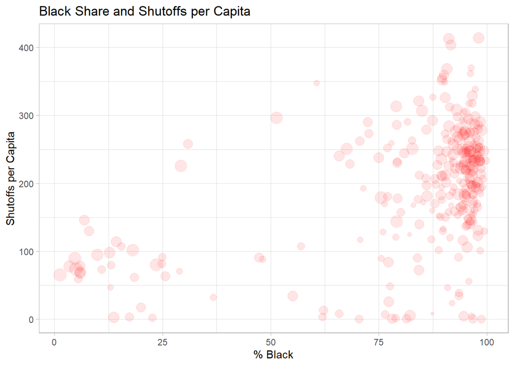

```r
ggplot(data = tract,
       aes(x = blackshare,
           y = si_1000,
           size = pop)) +
  geom_point(alpha = 0.1, color = "red") +
  scale_size(range = c(0.1, 6), guide = "none") +
  labs(title = "Black Share and Shutoffs per Capita", x = "% Black",
       y = "Shutoffs per Capita") +
  theme_light()
```

```r
wtd.cor(tract$blackshare, tract$si_1000, weight = tract$pop)
```

```
##   correlation    std.err  t.value      p.value
## Y   0.5144811 0.05035423 10.21724 3.918378e-21
```

## Visualize and interpret the relationship between median income and shutoffs per capita across census tracts in Detroit.

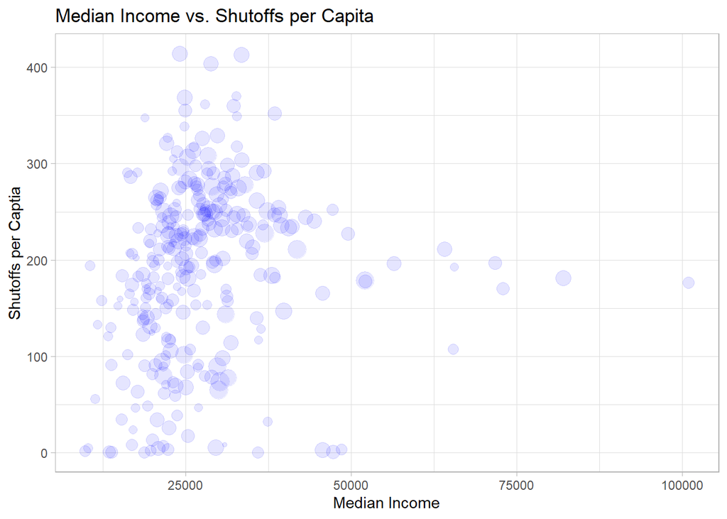

```r
ggplot(data = tract,
       aes(x = medianinc,
           y = si_1000,
           size = pop)) +
  geom_point(alpha = 0.1, color = "blue") +
  scale_size(range = c(0.1, 6), guide = "none") +
  labs(title = "Median Income vs. Shutoffs per Capita", x = "Median Income",
       y = "Shutoffs per Captia") +
  theme_light()
```

```r
wtd.cor(tract$medianinc, tract$si_1000, weight = tract$pop)
```

```
##   correlation    std.err  t.value    p.value
## Y   0.1254187 0.05825835 2.152802 0.03215895
```

## Visualize and interpret how shutoffs per capita relate to both Black share and median income on the *same* plot. Does race or income appear to be more salient?

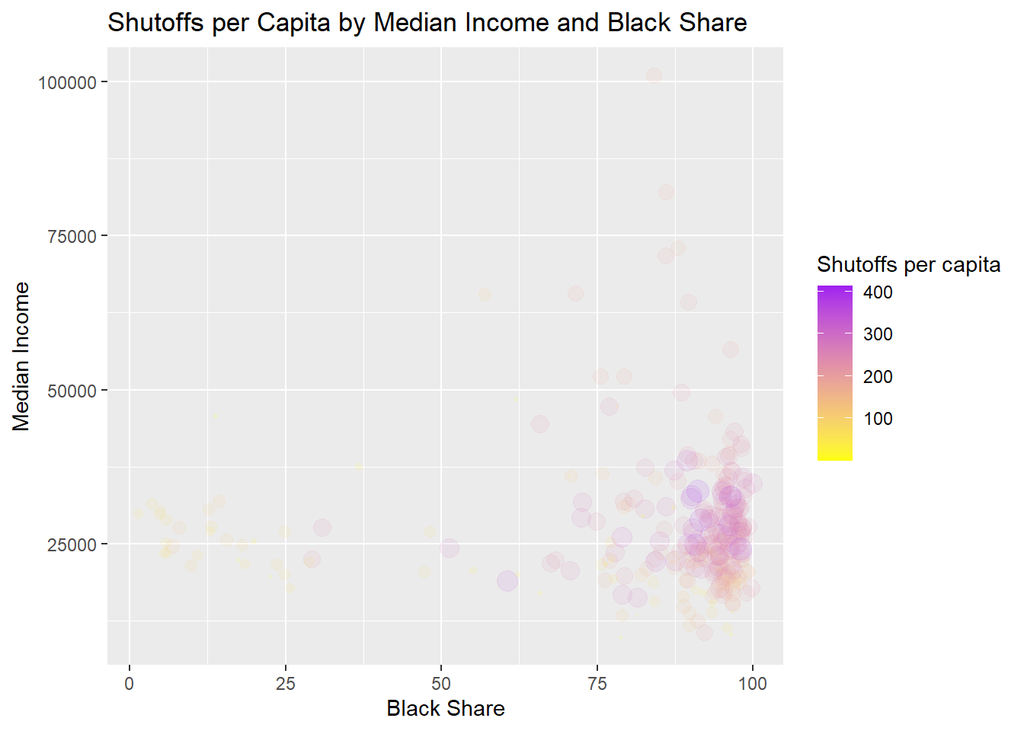

```r
ggplot(data = tract,
       aes(x = blackshare,
           y = medianinc,
           size = si_1000,
           color = si_1000)) +
  geom_point(alpha = 0.1) +
  scale_color_gradient(low = "yellow", high = "purple") +
  scale_size(range = c(0.1, 5), guide = "none") +
  labs(title = "Shutoffs per Capita by Median Income and Black Share", x = "Black Share", y = "Median Income",
       color = "Shutoffs per capita")
```

```r
wtd.cor(tract$blackshare, tract$medianinc, weight = tract$si_1000)
```

```
##    correlation   std.err    t.value   p.value
## Y -0.009079045 0.0587196 -0.1546169 0.8772309
```

# Time-series analysis.

In this section, we’ll explore variation *between* different groups of Census tracts and over time *within* groups (with groups defined based on tract-level income and racial composition).

## Plot and interpret the shutoffs per capita over time for tracts below/above citywide median housheold income (show two time series on a single plot).

```r
detroit_pop_hi_inc <- tract %>%
  filter(inc_above_median == 1) %>%
  summarise(sum(pop)) %>%
  as.numeric()

detroit_pop_lo_inc <- tract %>%
  filter(inc_above_median == 0) %>%
  summarise(sum(pop)) %>%
  as.numeric()

ym_inc <- tract_ym %>%
  group_by(date, inc_above_median) %>%
  summarise(si_count = sum(si_count)) %>%
  mutate(pop = if_else(inc_above_median == 1,
                       detroit_pop_hi_inc,
                       detroit_pop_lo_inc),
         si_1000 = si_count / (pop / 1000)) %>%
  na.omit()

ym_inc <- tract_ym %>%
  group_by(date, inc_above_median) %>%
  summarise(si_count = sum(si_count)) %>%
  na.omit() %>%
  ungroup() %>%
  complete(date,
           inc_above_median,
           fill = list(si_count = 0)) %>%
  mutate(pop = if_else(inc_above_median == 1,
                       detroit_pop_hi_inc,
                       detroit_pop_lo_inc),
         si_1000 = si_count / (pop / 1000))

ym_inc$inc_above_median <- factor(ym_inc$inc_above_median,
                                  levels = c(0,1),
                                  labels = c("Below median income",
                                             "Above median income"))
```

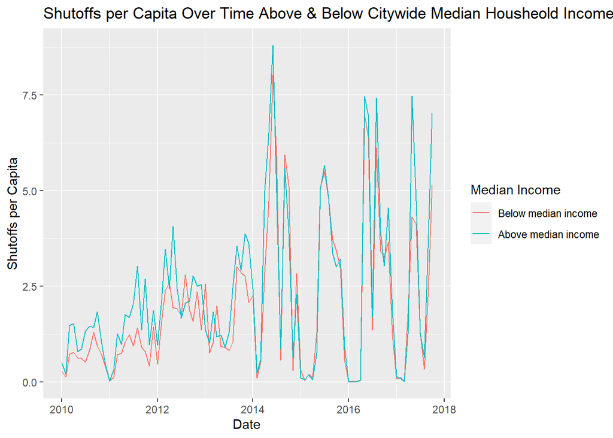

```r
ggplot(ym_inc,
       aes(x = date, y = si_1000, color = inc_above_median)) +
  geom_line() +
  labs(title = "Shutoffs per Capita Over Time Above & Below Citywide Median Housheold Income",
       x = "Date", y = "Shutoffs per Capita", color = "Median Income")
```

## Plot and interpret the shutoffs per capita over time for tracts that are at least 75% Black and those that aren’t (show two time series on a single plot).

```r
detroit_pop_black <- tract %>%
  filter(black75 == 1) %>%
  summarise(sum(pop)) %>%
  as.numeric()

detroit_pop_nblack <- tract %>%
  filter(black75 == 0) %>%
  summarise(sum(pop)) %>%
  as.numeric()

ym_race <- tract_ym %>%
  group_by(date, black75) %>%
  summarise(si_count = sum(si_count)) %>%
  na.omit() %>%
  ungroup() %>%
  complete(date, black75, fill = list(si_count = 0)) %>%
  mutate(pop = if_else(black75 == 1,
                       detroit_pop_black,
                       detroit_pop_nblack),
         si_1000 = si_count / (pop / 1000))

ym_race$black75 <- factor(ym_race$black75,
                                  levels = c(0,1),
                                  labels = c("Below 75% Black",
                                             "Above 75% Black"))
```

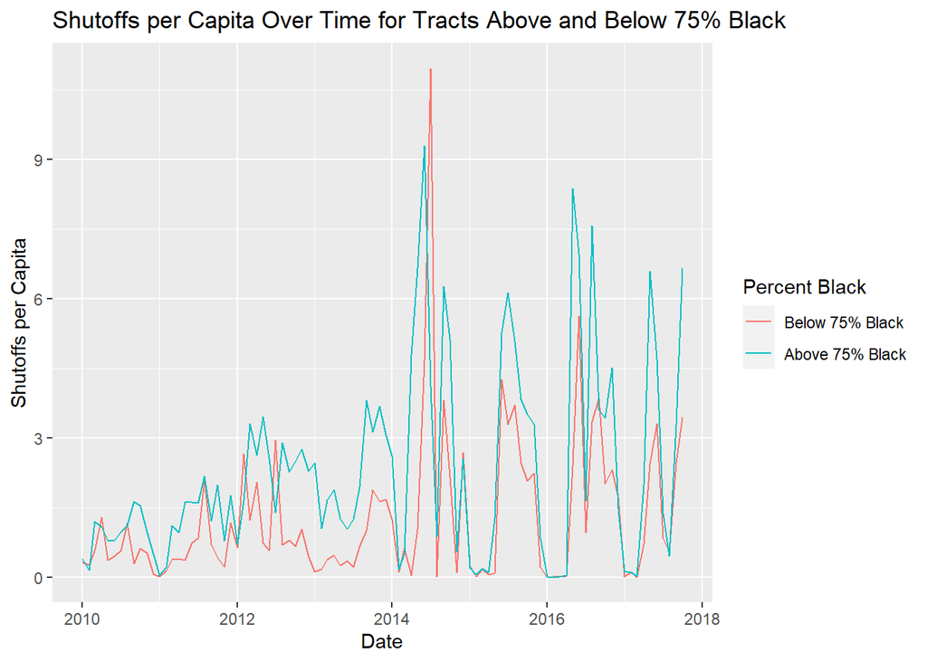

```r
ggplot(ym_race,
       aes(x = date, y = si_1000, color = black75)) +
  geom_line() +
  labs(title = "Shutoffs per Capita Over Time for Tracts Above and Below 75% Black",
       x = "Date", y = "Shutoffs per Capita", color = "Percent Black")
```

# Conclusion

## Based on the “cross-sectional” and time series analysis conducted above, does race or income appear to be a more important factor for explaining what type of households are most affected by the public water shutoffs? Explain.